# technical report (mainly 450k data, 15 GEO data sets used)

Qianhui

21/11/2018

This document is mainly for part4 of the GEO data set analysis, that is the filtering, backgroud correction step.

# 1. load data and packages

```r
library(tidyverse)
library(readxl)
library(minfi)
library(magrittr)
library(tibble)
library(data.table)
library(limma)
library(ewastools)
library(ENmix)
library(wateRmelon)
library(FactoMineR)
library(doParallel)
library(ggplot2)
library(RColorBrewer)
pal <- brewer.pal(8, "Dark2")

# GEOmeta, GEO_phenotypes
load(file = "/home/qianhui/DNAme/Process_decidual/RDSfiles/GEO_phenotypes_add10.RData")

#GEO_RGset_450k_normalPlacenta, GEO_phenoData_450k_normalPlacenta,
#GEO_RGset_EPIC_normalPlacenta, GEO_phenoData_EPIC_normalPlacenta,
#GEO_RGset_EPIC_normalPlacenta_ourStudy, GEO_phenoData_EPIC_normalPlacenta_ourStudy
load(file ="/home/qianhui/DNAme/Process_decidual/RDSfiles/GEO_RG&pData_normalPlacenta.RData")

#GEO_RGset_450k_Amnion, GEO_phenoData_450k_Amnion, GEO_RGset_EPIC_Amnion, GEO_phenoData_EPIC_Amnion
load(file ="/home/qianhui/DNAme/Process_decidual/RDSfiles/GEO_RG&pData_normalAmnion.RData")

#GEO_RGset_450k_Chorion, GEO_phenoData_450k_Chorion,GEO_RGset_EPIC_Chorion, GEO_phenoData_EPIC_Chorion
load(file ="/home/qianhui/DNAme/Process_decidual/RDSfiles/GEO_RG&pData_normalChorion.RData")

#GEO_RGset_450k_Decidua, GEO_phenoData_450k_Decidua, GEO_RGset_EPIC_Decidua, GEO_phenoData_EPIC_Decidua,
load(file ="/home/qianhui/DNAme/Process_decidual/RDSfiles/GEO_RG&pData_normalDecidua.RData")

#GEO_RGset_450k_MaternalBlood, GEO_phenoData_450k_MaternalBlood,
load(file ="/home/qianhui/DNAme/Process_decidual/RDSfiles/GEO_RG&pData_normalMaternalBlood.RData")

#GEO_RGset_450k_mesenchyme, GEO_phenoData_450k_mesenchyme
load(file ="/home/qianhui/DNAme/Process_decidual/RDSfiles/GEO_RG&pData_normalPlacentalMesenchyme.RData")

#GEO_RGset_450k_trophoblast, GEO_phenoData_450k_trophoblast
load(file ="/home/qianhui/DNAme/Process_decidual/RDSfiles/GEO_RG&pData_normalPlacentalTrophoblast.RData")

#GEO_RGset_450k_UC, GEO_phenoData_450k_UC
load(file ="/home/qianhui/DNAme/Process_decidual/RDSfiles/GEO_RG&pData_normalUmbilicalCord.RData")

#GEO_RGset_450k_UCB, GEO_phenoData_450k_UCB
load(file ="/home/qianhui/DNAme/Process_decidual/RDSfiles/GEO_RG&pData_normalUmbilicalCordBlood.RData")

# crossreactive probes-- EPIC
crossreactiveProbesEPIC <- read_csv("/home/qianhui/DNAme/Process-QH/13059_2016_1066_MOESM1_ESM-cross-reactive.csv")
colnames(crossreactiveProbesEPIC)[1] <- "ProbeNames"

# crossreactive probes--450k
crossreactiveProbes450k <- read_excel("/home/qianhui/DNAme/Process-QH/48639-non-specific-probes-Illumina450k.xlsx", sheet = 1)
colnames(crossreactiveProbes450k)[1] <- "ProbeNames"

# annotation needed for using functions
ann450k <- readRDS(file = "/home/qianhui/DNAme/Process_decidual/RDSfiles/ann450k_GEO15sets.rds")
annEPIC <- readRDS(file = "/home/qianhui/DNAme/Process_decidual/RDSfiles/annEPIC_GEO15sets.rds")
```

# 2. Sample and probe filtering & Background and dye bias correction & nomalisation

There are many tissue types for normal tissue samples around placenta, such as cord blood, chorionic plate and so on. We need to normalise different tissue separately.

There are 9 tissue types (we choose tissue types located near placenta) in total from GEO.

## A) Function for filtering and bg correction and normalisation

FilterFUN & use FilterFUN

TissueType argument in this function could be: Placenta, Amnion, Chorion, Decidua, Maternal whole blood, placental mesenchyme, placental trophoblast, umbilical cord, Umbilical cord blood.

### Function that need to be called in `FilterFUN`

```r
# Tissue: Amnoin, Chorion, Decidua, maternal whole blood, placental mesenchyme, placental trophoblast, umbilical cord and umbilical cord blood.

getRGset450K_extended <- function(Tissue){
  # base directory
  GEO_baseDir <- file.path("/home/qianhui/DNAme/Process_decidual/GEO_dataSets/IDAT_all")
  # get 450k meta data
  kept450k <- GEO_phenotypes$ArrayType=='450K'&
              !(GEO_phenotypes$Sample_name%in%c("GSM1617002_7668610068_R01C01","GSM1616993_7668610068_R06C02"))
  GEO_phenotypes_450k <- GEO_phenotypes[kept450k,]

  # get 450k, meta data for the tissue
  GEO_phenotypes_450k_Tissue <- GEO_phenotypes_450k %>%
  filter(str_detect(Sample, pattern=paste0("^", Tissue, "$"))) %>%
  filter(str_detect(Disease, pattern="Uncomplicated$"))
  # get the RGset for this tissue
  GEO_RGset_450k_Tissue_extended <- read.metharray.exp(base = GEO_baseDir,
                                                       targets = GEO_phenotypes_450k_Tissue,
                                                       extended = TRUE)
  return(GEO_RGset_450k_Tissue_extended)
}


## get normal tissue data, EPIC
getRGsetEPIC_extended <- function(Tissue){
  # base directory
  GEO_baseDir <- file.path("/home/qianhui/DNAme/Process_decidual/GEO_dataSets/IDAT_all")

  # get EPIC meta data
  GEO_phenotypes_EPIC <- GEO_phenotypes[GEO_phenotypes$ArrayType=='EPIC',]
  # get EPIC, meta data for the tissue
  GEO_phenotypes_EPIC_Tissue <- GEO_phenotypes_EPIC %>%
  filter(str_detect(Sample, pattern=paste0("^", Tissue, "$"))) %>%
  filter(str_detect(Disease, pattern="Uncomplicated$"))

  # # for out data 10 samples
  # GEO_phenotypes_EPIC_Tissue <- GEO_phenotypes_EPIC %>%
  # filter(str_detect(Sample, pattern=paste0("^", Tissue, "$"))) %>%
  # filter(str_detect(Disease, pattern="Uncomplicated$")) %>%
  # filter(str_detect(GEO_accession, pattern= "OurData"))

  # get the RGset for this tissue
  GEO_RGset_EPIC_Tissue_extended <- read.metharray.exp(base = GEO_baseDir,
                                              targets = GEO_phenotypes_EPIC_Tissue,
                                              extended = TRUE, force = TRUE)
  return(GEO_RGset_EPIC_Tissue_extended)
}
```

### Function `FilterFUN`

```r
  # dropSNP, dropXY: FALSE or TRUE; dropSNP=TRUE means drop all probes related with SNPs
  # annotation: ann450k or annEPIC, a DataFrame

FilterFun <- function(RGsetChara, crossreactiveProbes, annotation, tissueType,
                      DropSNP, DropXY, returnMset, returnBM){

  registerDoParallel(cores = 10)
  # get the object from character
  RGset <- get(RGsetChara)

  # get methylset
  if(ncol(RGset) ==1){
    methylset_raw <- preprocessIllumina(RGset, bg.correct = TRUE, normalize =  "no")

  } else {

    methylset_raw <- preprocessRaw(RGset) # 866238

  }


  # filtering of probes
  ## drop P
  detP <- minfi::detectionP(RGset)
  Failed <- detP > 0.01
  methylset_P <- methylset_raw[rowSums(Failed)==0,] #846991

  ## drop probes with <3 beads
  if(identical(annotation, ann450k)){

  EpicRGset_OneTissue_extended <- getRGset450K_extended(Tissue=tissueType)

  }else if(identical(annotation, annEPIC)){

  EpicRGset_OneTissue_extended <- getRGsetEPIC_extended(Tissue=tissueType)
  }

  BeadCount <- getNBeads(EpicRGset_OneTissue_extended)
  RemainProbe <- rowSums(BeadCount<3) < 0.05 * (ncol(BeadCount))
  EpicRGset_OneTissue_extended_Bead <- EpicRGset_OneTissue_extended[RemainProbe,]
  methylset_rawBead <- preprocessRaw(EpicRGset_OneTissue_extended_Bead) # bead number filter

  methylset_PBead <- methylset_P[rownames(methylset_P)%in%rownames(methylset_rawBead),] # 834351

  ## drop cross-reactive probes
  keep <- !(featureNames(methylset_PBead) %in% crossreactiveProbes$ProbeNames)
  methylset_PBeadX <- methylset_PBead[keep, ] # 792070

  ## drop SNPs
  ### if I use DropSNP argument, I drop all probes with SNPs
  if(DropSNP==TRUE){
  GRaSet_meth_PBeadX <- methylset_PBeadX %>% ratioConvert() %>% mapToGenome()
  GRaSet_meth_PBeadXAddSNPinfo <- addSnpInfo(GRaSet_meth_PBeadX)
  GRaSet_meth_PBeadXsnp <- dropLociWithSnps(GRaSet_meth_PBeadXAddSNPinfo,
                                  snps = c("CpG", "SBE", "Probe"), maf = 0)

  meth_PBeadXsnp <- methylset_PBeadX[rownames(methylset_PBeadX)%in% rownames(GRaSet_meth_PBeadXsnp), ]

  # saveRDS(meth_PBeadXsnp,
  #         file = paste0("/home/qianhui/DNAme/Process_decidual/RDSfiles/placenta_MethylSetRaw_GEOdrop_PBeadXsnp_butKeepXY_", tissueType, ".rds"))

  }else{
  ### else, I only drop unwanted SNP related probes, that is SNPs at CpG SBE sites
  GRaSet_meth_PBeadX <- methylset_PBeadX %>% ratioConvert() %>% mapToGenome()
  GRaSet_meth_PBeadXAddSNPinfo <- addSnpInfo(GRaSet_meth_PBeadX)
  GRaSet_meth_PBeadXsnp <- dropLociWithSnps(GRaSet_meth_PBeadXAddSNPinfo,
                                            snps = c("CpG", "SBE"), maf = 0)

  meth_PBeadXsnp <- methylset_PBeadX[rownames(methylset_PBeadX)%in% rownames(GRaSet_meth_PBeadXsnp), ]

  }

  ## drop probes on X, Y chr
  if(DropXY==TRUE){

  keep <- !(featureNames(meth_PBeadXsnp) %in% annotation$Name[annotation$chr %in% c("chrX", "chrY")])
  meth_PBeadXsnpXY <- meth_PBeadXsnp[keep, ] # 600k

  # saveRDS(methPlacenta_PBeadXsnpXY,
  #         file = "/home/qianhui/DNAme/Process_placenta_workflow/placenta_MethylSetRaw_GEOdrop_PBeadXsnpXY.rds")
  }else{

  meth_PBeadXsnpXY <- meth_PBeadXsnp
  }


  # bg correction
  filteredCpGs <- setdiff(featureNames(methylset_raw), featureNames(meth_PBeadXsnpXY))

  if(ncol(RGset) ==1){
  methylsetNormal_bgCorrENmix <- meth_PBeadXsnpXY
  } else {
  methylsetNormal_bgCorrENmix <- preprocessENmix(RGset, exCpG = filteredCpGs, nCores = 10)
  }


  # remove files not need
  rm(methylset_raw, EpicRGset_OneTissue_extended,
     GRaSet_meth_PBeadX, GRaSet_meth_PBeadXAddSNPinfo, GRaSet_meth_PBeadXsnp,
     meth_PBeadXsnpXY)


  # return(methylsetNormal_bgCorrENmix)
  if(returnMset==TRUE){
    return(methylsetNormal_bgCorrENmix)
  }

  # or return list containing beta and M values
  if(returnBM==TRUE){
    ## get beta values
    Normal_betaNorm <- minfi::getBeta(methylsetNormal_bgCorrENmix)
    ## calculate M values
    Normal_Mnorm <- log2(Normal_betaNorm/(1 - Normal_betaNorm))
    Normal_Mnorm_v1 <- Normal_Mnorm[apply(Normal_Mnorm, 1, function(x) all(is.finite(x))), ]

    BM_List <- list(Beta=Normal_betaNorm, M=Normal_Mnorm_v1)
    return(BM_List)
  }

}

# will write another function to do normalisation

  # do DMIQ normalisation
  # Normal_beta_bgCorr <- minfi::getBeta(methylsetNormal_bgCorrENmix)
  ## BMIQ output normalised beta values
  # Normal_betaNorm <- BMIQ(methylsetNormal_bgCorrENmix)
```

- I will do nomalisation in next Rmd document, because there are batch effects between GEO studies, I need to use BMIQ and modified BMIQ to normalise all data sets.

## B) Use the function FilterFUN to get bg corrected beta and M values for all the samples from 9 kinds of tissues located around placenta during early development.

- filter out failed samples first for GEO_RGset_450k_normalPlacenta[,5] (GSM1617002) and GEO_RGset_450k_MaternalBlood[,8] (GSM1616993).

These 2 failed samples are placental sample and maternal blood sample respectively, and both of them were from first trimester.

```r
# remove failed samples
GEO_RGset_450k_normalPlacenta_v1 <- GEO_RGset_450k_normalPlacenta[,-5]
GEO_RGset_450k_MaternalBlood_v1 <- GEO_RGset_450k_MaternalBlood[,-8]

TissueRGsetInfo <- data_frame(
  TissueRGsetNames=c("GEO_RGset_450k_normalPlacenta_v1", "GEO_RGset_EPIC_normalPlacenta",
                     "GEO_RGset_EPIC_normalPlacenta_ourStudy",
                      "GEO_RGset_450k_Amnion", "GEO_RGset_EPIC_Amnion",
                      "GEO_RGset_450k_Chorion", "GEO_RGset_EPIC_Chorion",
                      "GEO_RGset_450k_Decidua", "GEO_RGset_EPIC_Decidua",
                      "GEO_RGset_450k_MaternalBlood_v1", "GEO_RGset_450k_mesenchyme",
                      "GEO_RGset_450k_trophoblast",
                      "GEO_RGset_450k_UC", "GEO_RGset_450k_UCB"
                      ),
  TissueTypes=c(rep("Placenta", 3), rep("Amnion", 2), rep("Chorion", 2), rep("Decidua",2),
                "Maternal whole blood", "placental mesenchyme",
                "placental trophoblast", "umbilical cord", "Umbilical cord blood")
)



# mutiple samples for thses tissue types (use ENmix bg correction method)
# Tissue: Placenta, Amnoin, Chorion, Decidua, maternal whole blood, placental mesenchyme, placental trophoblast, umbilical cord and umbilical cord blood.

for(i in TissueRGsetInfo$TissueRGsetNames){

  if(str_detect(i, pattern ="450k")){

    assign(paste0("BM", str_replace(i, "GEO_RGset","")),
           FilterFun(RGsetChara = i,
                     crossreactiveProbes = crossreactiveProbes450k,
                     annotation = ann450k,
                     tissueType =TissueRGsetInfo[TissueRGsetInfo$TissueRGsetNames%in%i,]$TissueTypes,
                     DropSNP = TRUE, DropXY = TRUE,
                     returnMset = FALSE, returnBM = TRUE))

  }else if(str_detect(i, pattern ="EPIC")){

    assign(paste0("BM", str_replace(i, "GEO_RGset","")),
           FilterFun(RGsetChara = i,
                     crossreactiveProbes = crossreactiveProbesEPIC,
                     annotation = annEPIC,
                     tissueType =TissueRGsetInfo[TissueRGsetInfo$TissueRGsetNames%in%i,]$TissueTypes,
                     DropSNP = TRUE, DropXY = TRUE,
                     returnMset = FALSE, returnBM = TRUE))
  } # end if

} # end for
```

```
## 149187  CpGs were excluded before ENmix correction
## Analysis is running, please wait...!
```

```
## 245922  CpGs were excluded before ENmix correction
## Analysis is running, please wait...!
## 238674  CpGs were excluded before ENmix correction
## Analysis is running, please wait...!
## 134246  CpGs were excluded before ENmix correction
## Analysis is running, please wait...!
## 234739  CpGs were excluded before ENmix correction
## Analysis is running, please wait...!
## 137967  CpGs were excluded before ENmix correction
## Analysis is running, please wait...!
## 233808  CpGs were excluded before ENmix correction
## Analysis is running, please wait...!
## 230482  CpGs were excluded before ENmix correction
## Analysis is running, please wait...!
## 136650  CpGs were excluded before ENmix correction
## Analysis is running, please wait...!
## 136486  CpGs were excluded before ENmix correction
## Analysis is running, please wait...!
## 135755  CpGs were excluded before ENmix correction
## Analysis is running, please wait...!
## 134807  CpGs were excluded before ENmix correction
## Analysis is running, please wait...!
```

```r
save(
     list=c(paste0("BM", str_replace(TissueRGsetInfo$TissueRGsetNames, "GEO_RGset",""))),
     file = "/home/qianhui/DNAme/Process_decidual/RDSfiles/BMof9TissueTypes.RData")
```

## C) Use the function FilterFUN to get bg corrected Methyl sets for all the samples from 9 kinds of tissues located around placenta during early development.

```r
# remove failed samples
GEO_RGset_450k_normalPlacenta_v1 <- GEO_RGset_450k_normalPlacenta[,-5]
GEO_RGset_450k_MaternalBlood_v1 <- GEO_RGset_450k_MaternalBlood[,-8]

TissueRGsetInfo <- data_frame(
  TissueRGsetNames=c("GEO_RGset_450k_normalPlacenta_v1", "GEO_RGset_EPIC_normalPlacenta",
                     "GEO_RGset_EPIC_normalPlacenta_ourStudy",
                      "GEO_RGset_450k_Amnion", "GEO_RGset_EPIC_Amnion",
                      "GEO_RGset_450k_Chorion", "GEO_RGset_EPIC_Chorion",
                      "GEO_RGset_450k_Decidua", "GEO_RGset_EPIC_Decidua",
                      "GEO_RGset_450k_MaternalBlood_v1", "GEO_RGset_450k_mesenchyme",
                      "GEO_RGset_450k_trophoblast",
                      "GEO_RGset_450k_UC", "GEO_RGset_450k_UCB"
                      ),
  TissueTypes=c(rep("Placenta", 3), rep("Amnion", 2), rep("Chorion", 2), rep("Decidua",2),
                "Maternal whole blood", "placental mesenchyme",
                "placental trophoblast", "umbilical cord", "Umbilical cord blood")
)


# mutiple samples for thses tissue types (use ENmix bg correction method)
# Tissue: Placenta, Amnoin, Chorion, Decidua, maternal whole blood, placental mesenchyme, placental trophoblast, umbilical cord and umbilical cord blood.

for(i in TissueRGsetInfo$TissueRGsetNames){

  if(str_detect(i, pattern ="450k")){

    assign(paste0("Mset", str_replace(i, "GEO_RGset","")),
           FilterFun(RGsetChara = i,
                     crossreactiveProbes = crossreactiveProbes450k,
                     annotation = ann450k,
                     tissueType =TissueRGsetInfo[TissueRGsetInfo$TissueRGsetNames%in%i,]$TissueTypes,
                     DropSNP = TRUE, DropXY = TRUE,
                     returnMset = TRUE, returnBM = FALSE))

  }else if(str_detect(i, pattern ="EPIC")){

    assign(paste0("Mset", str_replace(i, "GEO_RGset","")),
           FilterFun(RGsetChara = i,
                     crossreactiveProbes = crossreactiveProbesEPIC,
                     annotation = annEPIC,
                     tissueType =TissueRGsetInfo[TissueRGsetInfo$TissueRGsetNames%in%i,]$TissueTypes,
                     DropSNP = TRUE, DropXY = TRUE,
                     returnMset = TRUE, returnBM = FALSE))
  } # end if

} # end for
```

```
## 149187  CpGs were excluded before ENmix correction
## Analysis is running, please wait...!
## 245922  CpGs were excluded before ENmix correction
## Analysis is running, please wait...!
## 238674  CpGs were excluded before ENmix correction
## Analysis is running, please wait...!
## 134246  CpGs were excluded before ENmix correction
## Analysis is running, please wait...!
## 234739  CpGs were excluded before ENmix correction
## Analysis is running, please wait...!
## 137967  CpGs were excluded before ENmix correction
## Analysis is running, please wait...!
## 233808  CpGs were excluded before ENmix correction
## Analysis is running, please wait...!
## 230482  CpGs were excluded before ENmix correction
## Analysis is running, please wait...!
## 136650  CpGs were excluded before ENmix correction
## Analysis is running, please wait...!
## 136486  CpGs were excluded before ENmix correction
## Analysis is running, please wait...!
## 135755  CpGs were excluded before ENmix correction
## Analysis is running, please wait...!
## 134807  CpGs were excluded before ENmix correction
## Analysis is running, please wait...!
```

```r
save(
     # Mset_450k_normalPlacenta_v1, Mset_EPIC_normalPlacenta,
     # Mset_450k_Amnion, Mset_EPIC_Amnion,
     # Mset_450k_Chorion, Mset_EPIC_Chorion,
     # Mset_450k_Decidua, Mset_EPIC_Decidua,
     # Mset_450k_MaternalBlood_v1, Mset_450k_mesenchyme,
     # Mset_450k_trophoblast, Mset_450k_UC, Mset_450k_UCB,
     list=c(paste0("Mset", str_replace(TissueRGsetInfo$TissueRGsetNames, "GEO_RGset",""))),
     file = "/home/qianhui/DNAme/Process_decidual/RDSfiles/MsetsOf9TissueTypes.RData")
```

# 3. MDS plot using all data

## A) Function `plotMDSFUN`

```r
# phenoData: GEO_phenotypes, meta data for all samples
# Array: "450k" or "EPIC"

plotMDSFUN <- function(Normal_betaNorm, Tissue, PhenoData, Array, Study,...){
  registerDoParallel(cores = 10)

  if(Array == "450k"){

  GEO_phenotypes_450k <- GEO_phenotypes[GEO_phenotypes$ArrayType=='450K',]
  # get 450k, meta data for the tissue
  GEO_phenotypes_Tissue <- GEO_phenotypes_450k %>%
  filter(str_detect(Sample, pattern=paste0("^", Tissue, "$"))) %>%
  filter(str_detect(Disease, pattern="Uncomplicated$"))

  }else if(Array == "EPIC"){

  GEO_phenotypes_EPIC <- GEO_phenotypes[GEO_phenotypes$ArrayType=='EPIC',]
  # get EPIC, meta data for the tissue
  GEO_phenotypes_Tissue <- GEO_phenotypes_EPIC %>%
  filter(str_detect(Sample, pattern=paste0("^", Tissue, "$"))) %>%
  filter(str_detect(Disease, pattern="Uncomplicated$"))

  }

  if(Study=="ourStudy"){
  GEO_phenotypes_EPIC <- GEO_phenotypes[GEO_phenotypes$ArrayType=='EPIC',]
  # get EPIC, meta data for the tissue
  GEO_phenotypes_Tissue <- GEO_phenotypes_EPIC %>%
  filter(str_detect(Sample, pattern=paste0("^", Tissue, "$"))) %>%
  filter(str_detect(Study, pattern="ourStudy"))
  }

  # then get beta values for each tissue type
  Normal_betaNorm_forPlot <- get(Normal_betaNorm)$Beta

  # plotMDS plots
  if(Normal_betaNorm=="BM_450k_normalPlacenta_v1"){
     label <- GEO_phenotypes_Tissue$Trimester[-5]
  }else if(Normal_betaNorm=="BM_450k_MaternalBlood_v1"){
     label <- GEO_phenotypes_Tissue$Trimester[-8]
  }else{
     label <- GEO_phenotypes_Tissue$Trimester
  } # end if

  if(ncol(Normal_betaNorm_forPlot)>=3){
  par(mfrow=c(1,1), ...)
  plotMDS(Normal_betaNorm_forPlot, top=nrow(Normal_betaNorm_forPlot),
          main=Tissue,  labels= label, gene.selection="common")
  }
  # labels= label, col= pal[factor(label)],

  # plot density plot anagin with other 96 samples
  par(mfrow=c(1,1), cex=0.8, ...)
  densityPlot(Normal_betaNorm_forPlot, sampGroups = label,
              main=Tissue, xlab = "Normalised Beta values")

}# end function
```

## B) Use function `plotMDSFUN`

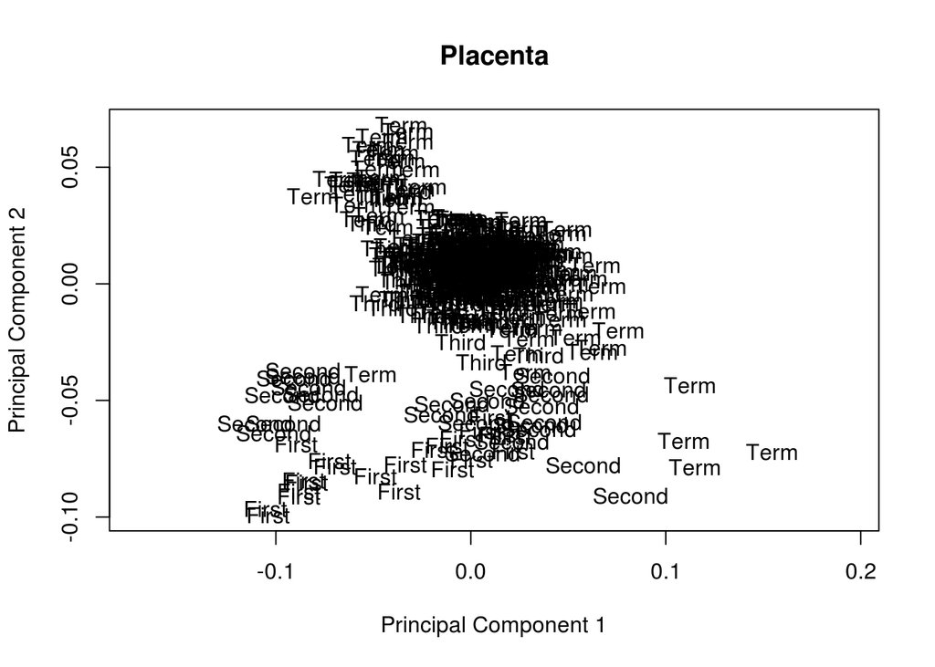

```
## Error in xy.coords(x, y, xlabel, ylabel, log): 'x' and 'y' lengths differ
```

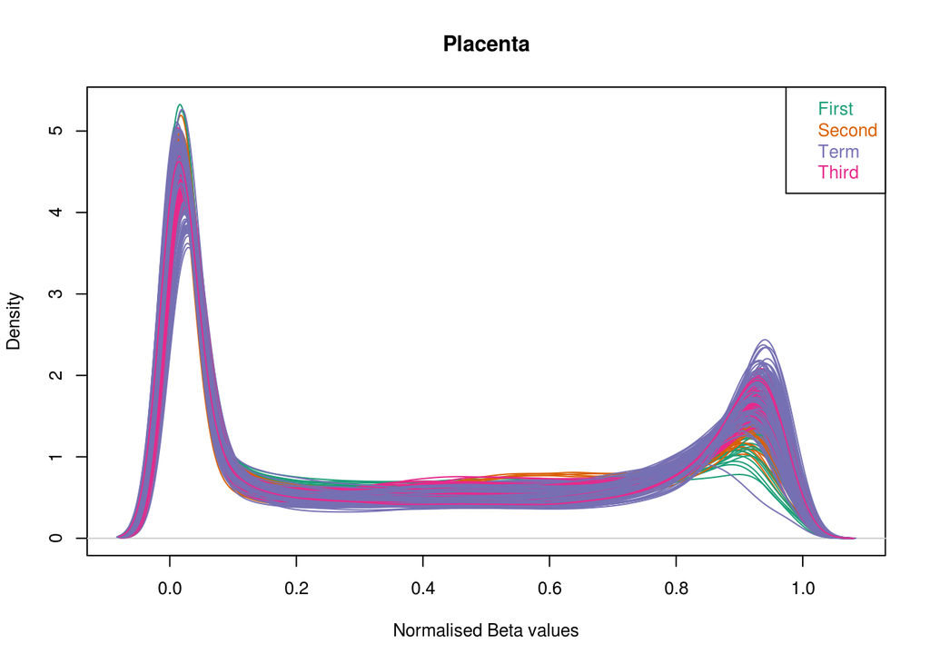

```r
TissueBMvalInfo <- data_frame(
  TissueBMvalNames=c("BM_450k_normalPlacenta_v1", "BM_EPIC_normalPlacenta",
                     "BM_EPIC_normalPlacenta_ourStudy",
                     "BM_450k_Amnion", "BM_EPIC_Amnion",
                     "BM_450k_Chorion", "BM_EPIC_Chorion",
                     "BM_450k_Decidua", "BM_EPIC_Decidua",
                     "BM_450k_MaternalBlood_v1", "BM_450k_mesenchyme",
                     "BM_450k_trophoblast",
                     "BM_450k_UC", "BM_450k_UCB"
                      ),
  TissueTypes=c(rep("Placenta", 3), rep("Amnion", 2), rep("Chorion", 2), rep("Decidua",2),
                "Maternal whole blood", "placental mesenchyme",
                "placental trophoblast", "umbilical cord", "Umbilical cord blood")
)


# use plotMDSFUN function
for(i in TissueBMvalInfo$TissueBMvalNames){

  plotMDSFUN(Normal_betaNorm = i,
             Tissue = TissueBMvalInfo[TissueBMvalInfo$TissueBMvalNames%in%i,]$TissueTypes,
             PhenoData = GEO_phenotypes,
             Array = ifelse(str_detect(i, pattern = "450k"), "450k", "EPIC"),
             Study = ifelse(str_detect(i, pattern = "ourStudy"), "ourStudy", "PublicStudy"))
}
```

## C) left_join all beta values and plot in one MDS plot

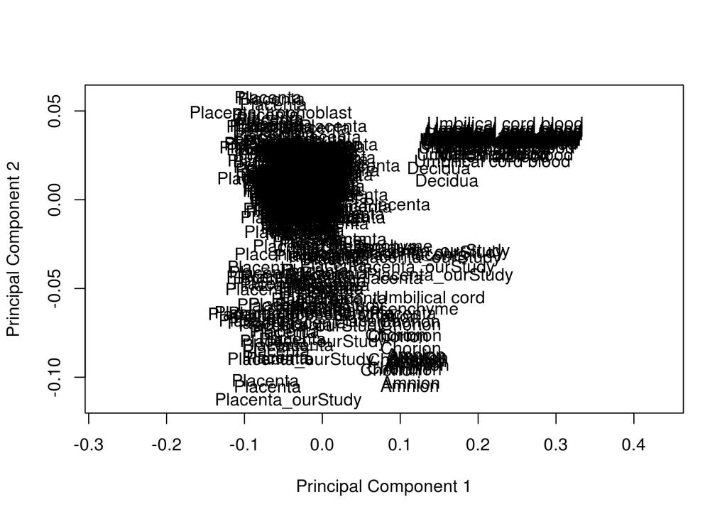

```r
registerDoParallel(cores = 10)

ListToJoin <- list(

BM_450k_normalPlacenta_v1.df = BM_450k_normalPlacenta_v1$Beta %>% as.data.frame() %>% rownames_to_column(var="Probe"),
BM_EPIC_normalPlacenta.df = BM_EPIC_normalPlacenta$Beta %>% as.data.frame() %>% rownames_to_column(var="Probe"),
BM_EPIC_normalPlacenta_ourStudy.df = BM_EPIC_normalPlacenta_ourStudy$Beta %>% as.data.frame() %>% rownames_to_column(var="Probe"),

BM_450k_Amnion.df = BM_450k_Amnion$Beta %>% as.data.frame() %>% rownames_to_column(var="Probe"),
BM_EPIC_Amnion.df = BM_EPIC_Amnion$Beta %>% as.data.frame() %>% rownames_to_column(var="Probe"),

BM_450k_Chorion.df = BM_450k_Chorion$Beta %>% as.data.frame() %>% rownames_to_column(var="Probe"),
BM_EPIC_Chorion.df = BM_EPIC_Chorion$Beta %>% as.data.frame() %>% rownames_to_column(var="Probe"),

BM_450k_Decidua.df = BM_450k_Decidua$Beta %>% as.data.frame() %>% rownames_to_column(var="Probe"),
BM_EPIC_Decidua.df = BM_EPIC_Decidua$Beta %>% as.data.frame() %>% rownames_to_column(var="Probe"),

BM_450k_MaternalBlood_v1.df = BM_450k_MaternalBlood_v1$Beta %>% as.data.frame() %>% rownames_to_column(var="Probe"),

BM_450k_mesenchyme.df = BM_450k_mesenchyme$Beta %>% as.data.frame() %>% rownames_to_column(var="Probe"),

BM_450k_trophoblast.df = BM_450k_trophoblast$Beta %>% as.data.frame() %>% rownames_to_column(var="Probe"),

BM_450k_UC.df = BM_450k_UC$Beta %>% as.data.frame() %>% rownames_to_column(var="Probe"),

BM_450k_UCB.df = BM_450k_UCB$Beta %>% as.data.frame() %>% rownames_to_column(var="Probe")

)

Join.df <- ListToJoin %>% purrr::reduce(left_join, by = "Probe")

Join.df_v1 <- na.omit(Join.df)

Join.df_v2 <- Join.df_v1 %>% remove_rownames() %>%
  column_to_rownames(var="Probe") %>% as.matrix() # 298179

#plotMDS plots
## get labels (label the tissue types) for each sample
Tissues <-str_replace_all(names(ListToJoin), c("BM_450k_|BM_EPIC_"="", "_v1.df|.df"=""))
Tissues_v1 <-str_replace_all(Tissues, c("normalPlacenta"="Placenta",
                                        "mesenchyme"="Placental mesenchyme",
                                        "trophoblast"="Placental trophoblast",
                                        "UCB"="Umbilical cord blood",
                                        "UC"="Umbilical cord"))

freq <- lapply(ListToJoin, FUN = function(x){ncol(x)-1}) %>% unlist() %>% as.integer()
label <- rep(Tissues_v1, freq)

## phenodata for these samples
GEO_phenotypes_joinedSamples <- GEO_phenotypes[match(colnames(Join.df_v2),GEO_phenotypes$Sample_name),]

## plot MDS plot
par(mfrow=c(1,1))
MDS_joinedSamples <- plotMDS(Join.df_v2, top=nrow(Join.df_v2), labels= label, gene.selection="common") # labels= label, col= pal[factor(label)],
```

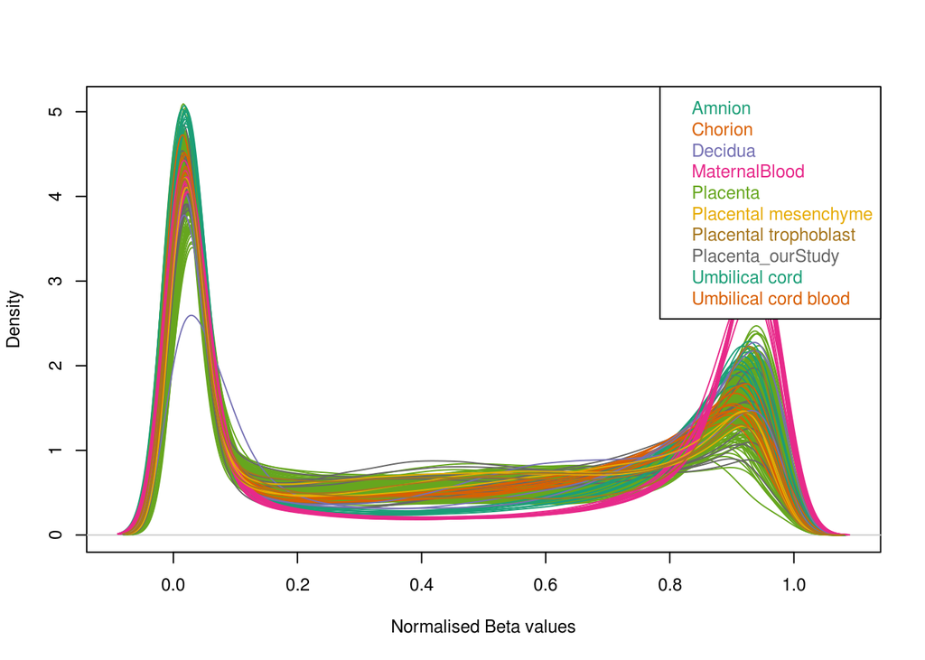

```r
# plot density plot anagin with other 96 samples
par(mfrow=c(1,1), cex=0.8)
densityPlot(Join.df_v2, sampGroups = label, xlab = "Normalised Beta values")
```

```r
save(Join.df_v2, GEO_phenotypes_joinedSamples, MDS_joinedSamples,
     file = "/home/qianhui/DNAme/Process_decidual/RDSfiles/GEO_joinedSamples551_Beta_MDS.RData")
```

## D) 1 MDS for all 551 samples

```r
library(RColorBrewer)
colorFun <- colorRampPalette(brewer.pal(9, "Set1"))
pal2 <- colorFun(13)

# Join.df_v2, label, GEO_phenotypes_joinedSamples, MDS_joinedSamples,
# load(file = "/home/qianhui/DNAme/Process_decidual/RDSfiles/GEO_joinedSamples551_Beta_MDS.RData")

# set up nes df for ggplot
## check sample orders were the same or not
table(colnames(Join.df_v2)==GEO_phenotypes_joinedSamples$Sample_name)
```

```
##
## TRUE
##  551
```

```r
new_plotDF <- data.frame(MDS_joinedSamples$x,
    MDS_joinedSamples$y,
    GA = GEO_phenotypes_joinedSamples$Gestation,
    FetalSex= GEO_phenotypes_joinedSamples$Fetal_Sex,
    Tissue=str_replace_all(GEO_phenotypes_joinedSamples$Sample, c(
                                        "placental"="Placental",
                                        "umbilical"="Umbilical")),
    Trimester=GEO_phenotypes_joinedSamples$Trimester,
    Study=GEO_phenotypes_joinedSamples$Study

)

colnames(new_plotDF) <- c("x", "y", "Gestational age", "FetalSex", "Tissue", "Trimester", "Study")

# Plot the new dataframe
## color to use
namedPal2 <- pal2 %>% `names<-`(unique(new_plotDF$Tissue))
TissueShape <- factor(new_plotDF$Tissue)

MDSplot_joinedSamples <- new_plotDF %>%
  ggplot(aes(x, y)) +
  geom_point(aes(shape = Study, col=Trimester), alpha = 1, size = 5)+
  # scale_color_manual(values = namedPal2)+
  scale_shape_manual(values=1:length(new_plotDF$Study))+
  labs(x="Dimension 1", y="Dimension 2")+
  theme(text = element_text(size=20))
# axis.text.x = element_text(angle=90, hjust=1))


# save the MDS plot as pdf:
pdf(file = "/home/qianhui/DNAme/Process_decidual/figures/MDSplot-noNormalise_joinedGEOsamples551.pdf",
    width = 13, height = 7)

theme_set(theme_bw())
MDSplot_joinedSamples
dev.off()
```

```r
# save as tiff
tiff(file = "/home/qianhui/DNAme/Process_decidual/figures/MDSplot-noNormalise_joinedGEOsamples551.tiff",
     width = 20,height = 15, units="cm",  res = 300)

theme_set(theme_bw())
MDSplot_joinedSamples
dev.off()
```

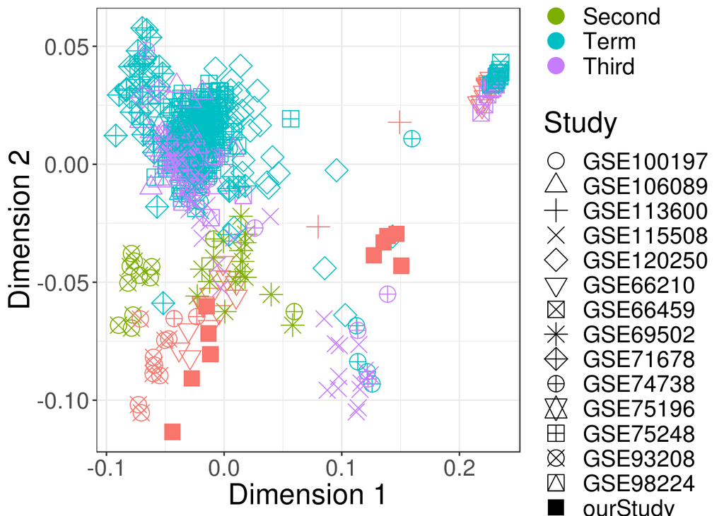

```r
## show some plots
###(1)
theme_set(theme_bw())
MDSplot_joinedSamples
```

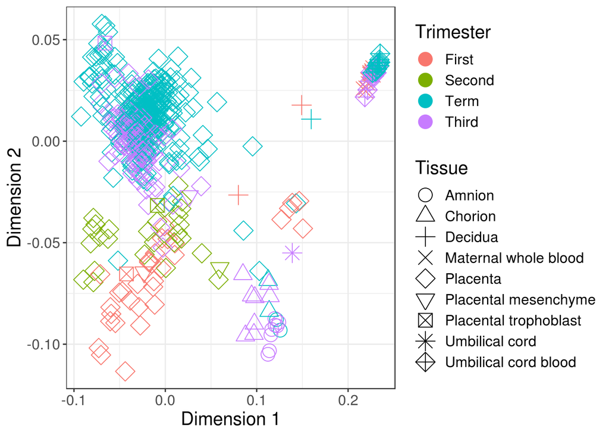

```r
###(2)
new_plotDF %>%
  ggplot(aes(x, y)) +
  geom_point(aes(shape = Tissue, col=Trimester), alpha = 1, size = 5)+
  # scale_color_manual(values = namedPal2)+
  scale_shape_manual(values=1:nlevels(TissueShape))+
  labs(x="Dimension 1", y="Dimension 2")+
  theme(text = element_text(size=15))
```

- There seems to be batch effects between studies, so we need to remove batch effects before doing MDS and other downstream analysis. I will adjusted for batch use Combat or modified BMIQ function by Horvath.